# RNAseq analysis of OSMR and LIFR

Arjan Boltjes

11/12/2018

## Introduction

Request: compare gene expression of two genes - OSMR and LIFR - between plaque stability scores and between genotypes.  
Variants involved:  
- rs13168867 associates with OSMR  
- rs10491509 associates with LIFR

## Vulnerability data

Import data and have a look at the variable names

```
## [1] "var00006"          "upid"              "sampleid_aegs"
## [4] "rs10491509"        "var00011"          "rs13168867"
## [7] "study_number"      "upid_study_number" "stability"
```

Select variables and check dataframe

```
## # A tibble: 1,594 x 4
##    study_number rs10491509 rs13168867 stability
##           <dbl> <fct>      <fct>      <fct>
##  1          916 GG         CC         2
##  2          703 00         CT         2
##  3          411 AA         CC         3
##  4          906 AA         CT         2
##  5         1527 GG         TT         1
##  6          797 GG         TT         2
##  7         1868 00         CC         2
##  8          999 GG         TT         0
##  9         1789 AG         CC         2
## 10          335 AG         TT         3
## # ... with 1,584 more rows
```

Take a sneak peak at the distribution of the samples over the different scores and genotypes

Stability:

```
##
##    0    1    2    3    4 <NA>
##  196  379  565  238   90  126
```

rs10491509 genotype:

```
##
##  GG  AG  AA  00
## 653 663 158  52  68
```

rs13168867 genotype:

```
##
##   TT   CT   CC      <NA>
##  550  710  264   68    2
```

From these numbers, we can see that all scores and genotypes are represented in the data, and that there are several samples with missing data

# Subset 30 RNAseq patients, select phenotypes and combine with RNAseq data

The RNAseq data only contains 30 patients. Therefore we subset these 30 patients from the vulnerability data, based on study number.

```
## # A tibble: 30 x 4
##    study_number rs10491509 rs13168867 stability
##           <dbl> <fct>      <fct>      <fct>
##  1         1267 AG         TT         2
##  2         1343 AA         CT         1
##  3         1373 AG         CC         1
##  4         1374 GG         CT         2
##  5         1376 AG         CT         1
##  6         1407 GG         CC         2
##  7         1504 GG         TT         2
##  8         1858 AG         CT         3
##  9         1932 00         CC         2
## 10         2117 GG         CC         2
## # ... with 20 more rows
```

```
## class: RangedSummarizedExperiment
## dim: 57773 30
## metadata(0):
## assays(1): counts
## rownames: NULL
## rowData names(1): feature_id
## colnames(30): 1267 1343 ... 2388 936
## colData names(4): study_number rs10491509 rs13168867 stability
```

If we look at the distribution of this subsetted data over the scores and genotypes, we see the following.

**Figure 1. Distribution of RNAseq samples over the different vulnerability scores**

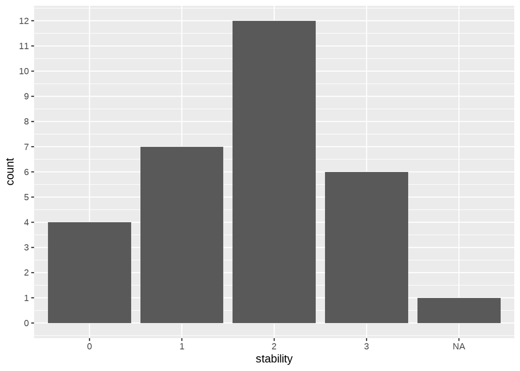

**Figure 2. Distribution of RNAseq samples over rs10491509 genotypes**

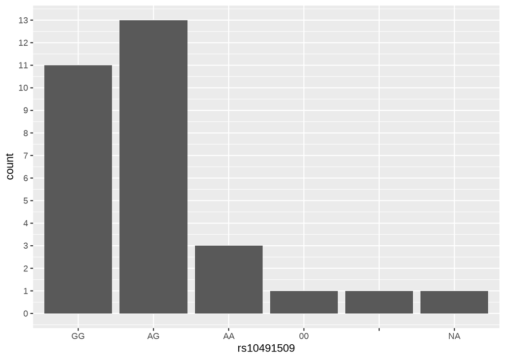

**Figure 3. Distribution of RNAseq samples over rs13168867 genotypes**

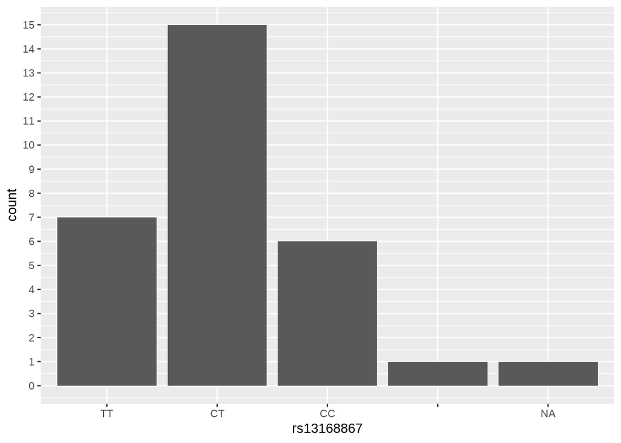

When going through these plots, one can immediately see that among our 30 patients of which we have RNAseq data, one is not contained in the vulnerability dataset (NA in all three plots).  
Furthermore, none of the samples have a stability score of 4. And genotype data is missing for 1-2 people (denominated “” or “00”).

# **OSMR expression**

If we then plot our RNAseq data over these three variables we get the following:

**Figure 4. Comparing OSMR expression between plaque stability scores**

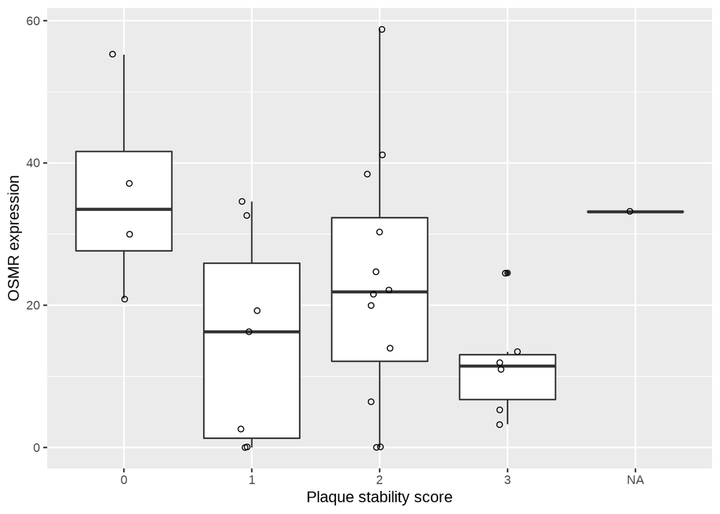

**Figure 5. Comparing OSMR expression between rs10491509 genotypes**

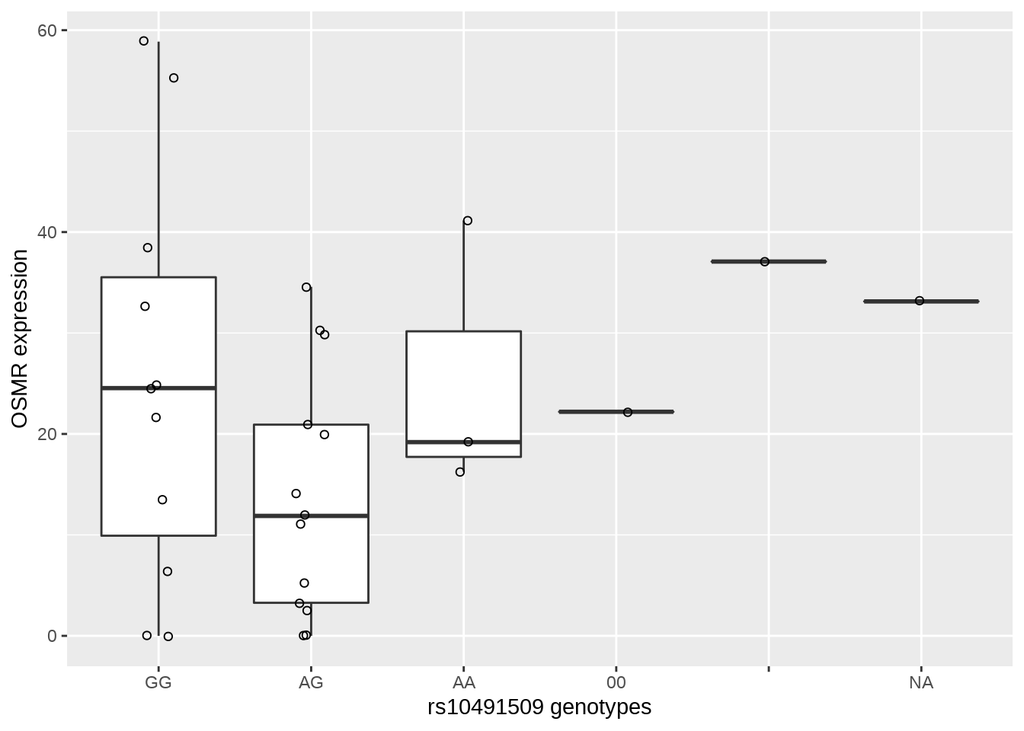

**Figure 6. Comparing OSMR expression between rs13168867 genotypes**

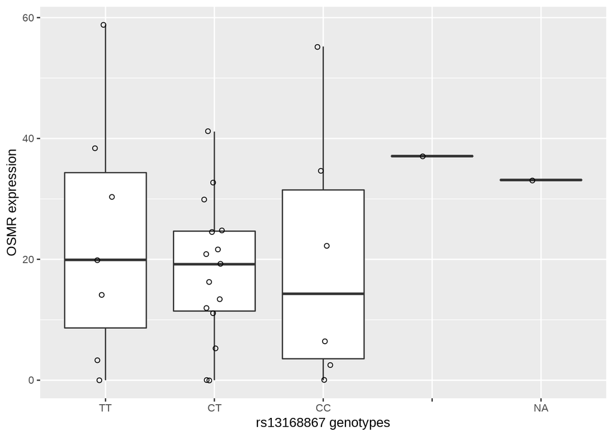

## *Same plots, without NA, 00, and empty:*

**Figure 7. Comparing OSMR expression between plaque stability scores**

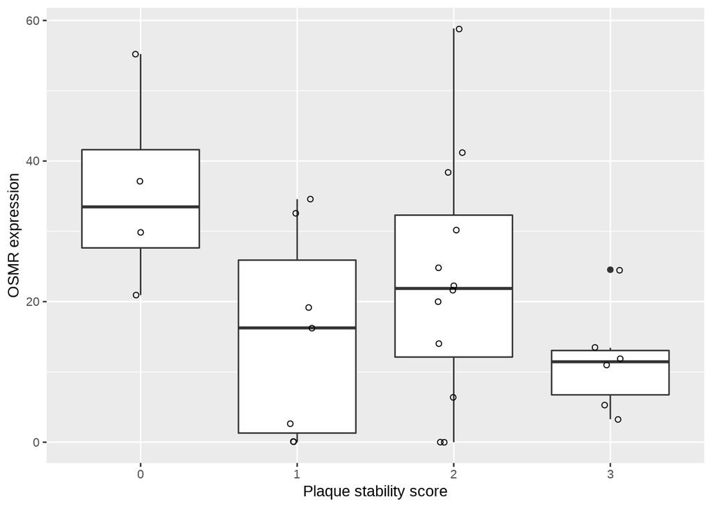

**Figure 8. Comparing OSMR expression between rs10491509 genotypes**

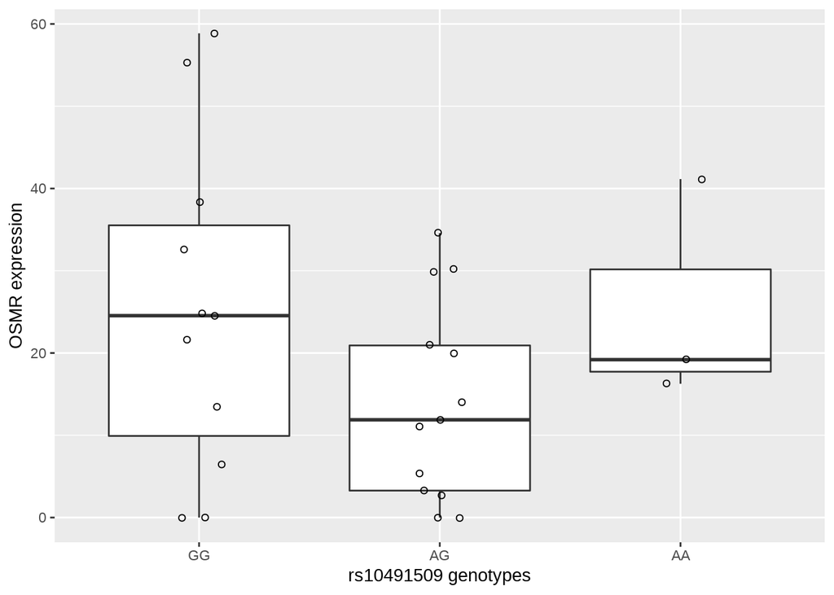

**Figure 9. Comparing OSMR expression between rs13168867 genotypes**

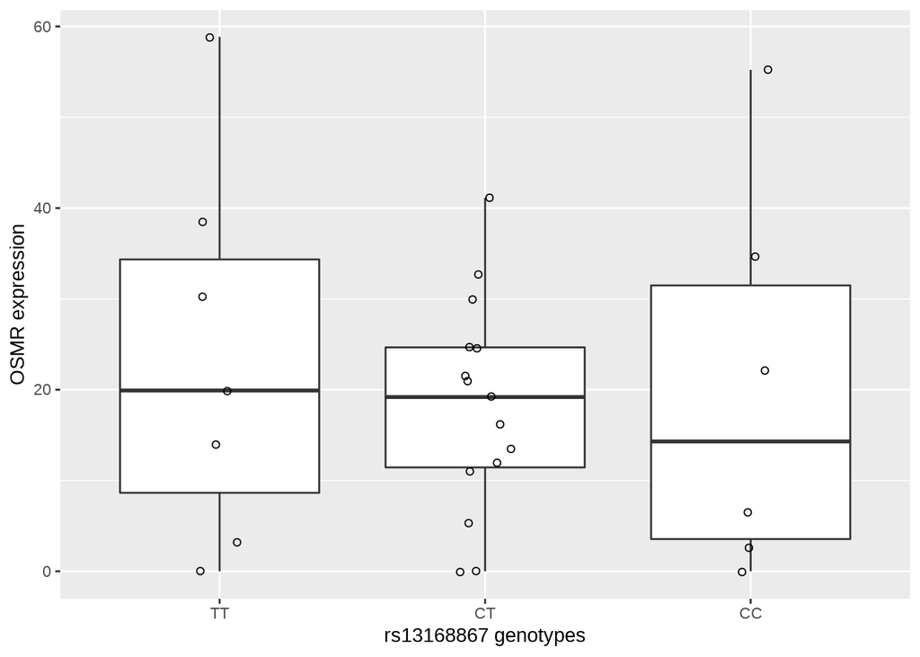

# LIFR expression

**Figure 10. Comparing LIFR expression between plaque stability scores**

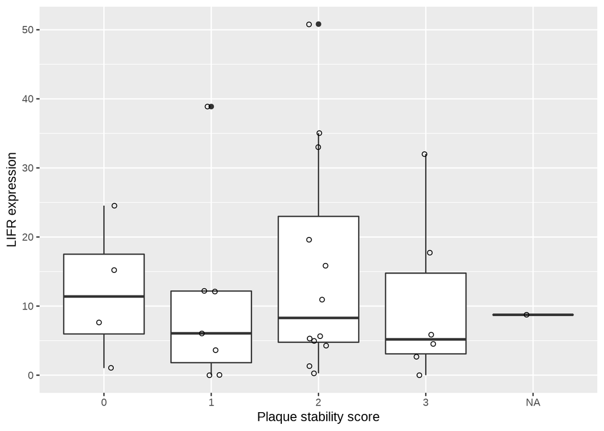

**Figure 11. Comparing LIFR expression between rs10491509 genotypes**

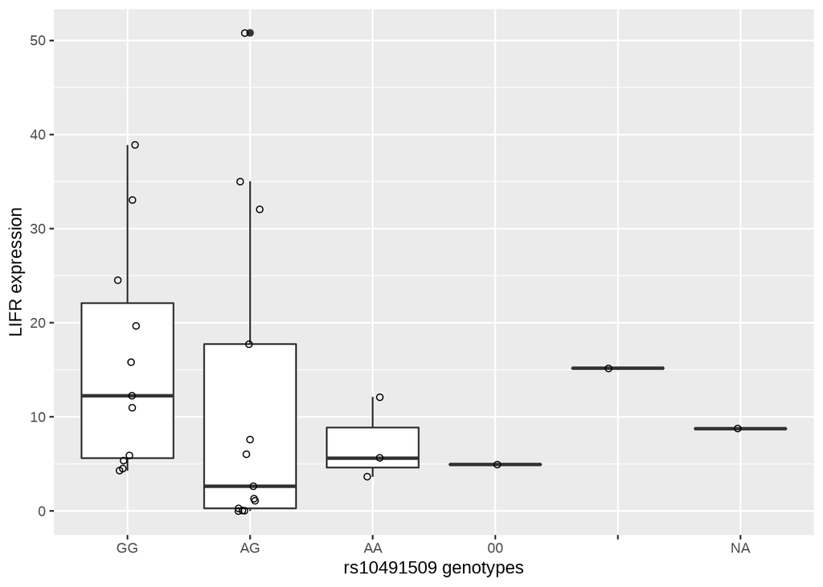

**Figure 12. Comparing LIFR expression between rs13168867 genotypes**

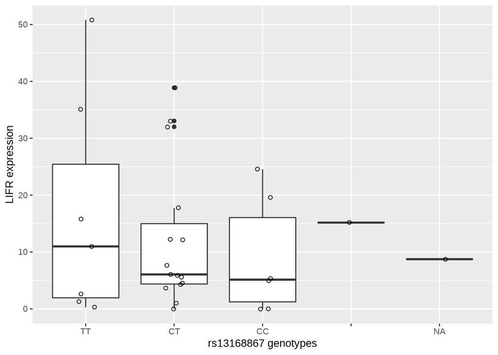

# *Same plots, without NA, 00, and empty:*

**Figure 13. Comparing LIFR expression between plaque stability scores**

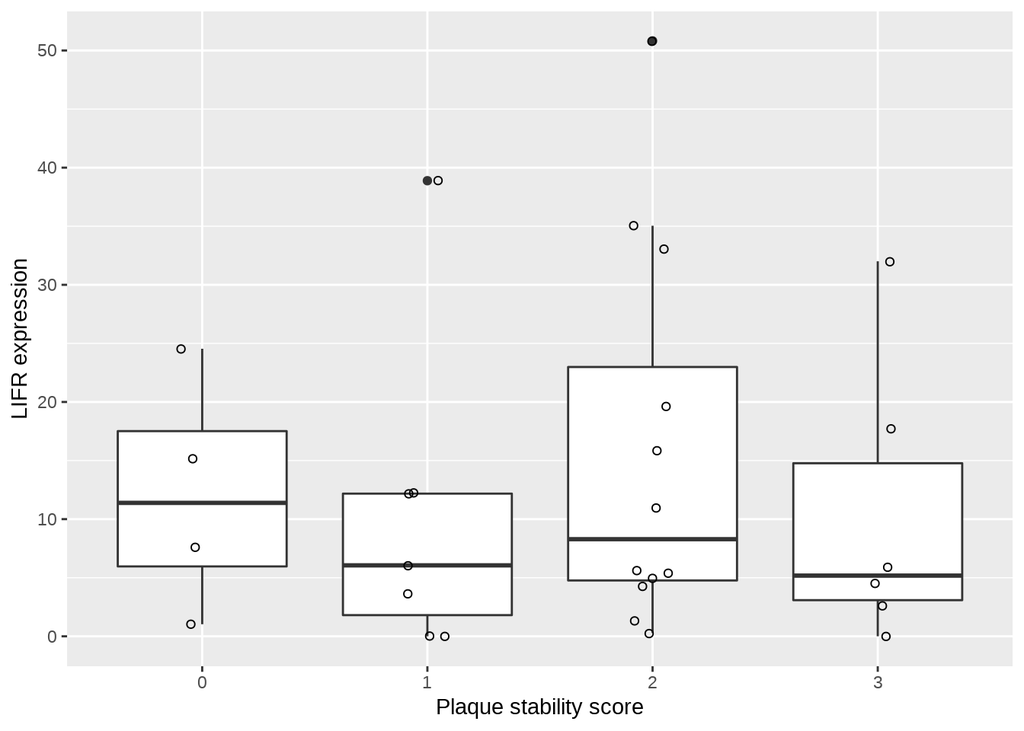

**Figure 14. Comparing LIFR expression between rs10491509 genotypes**

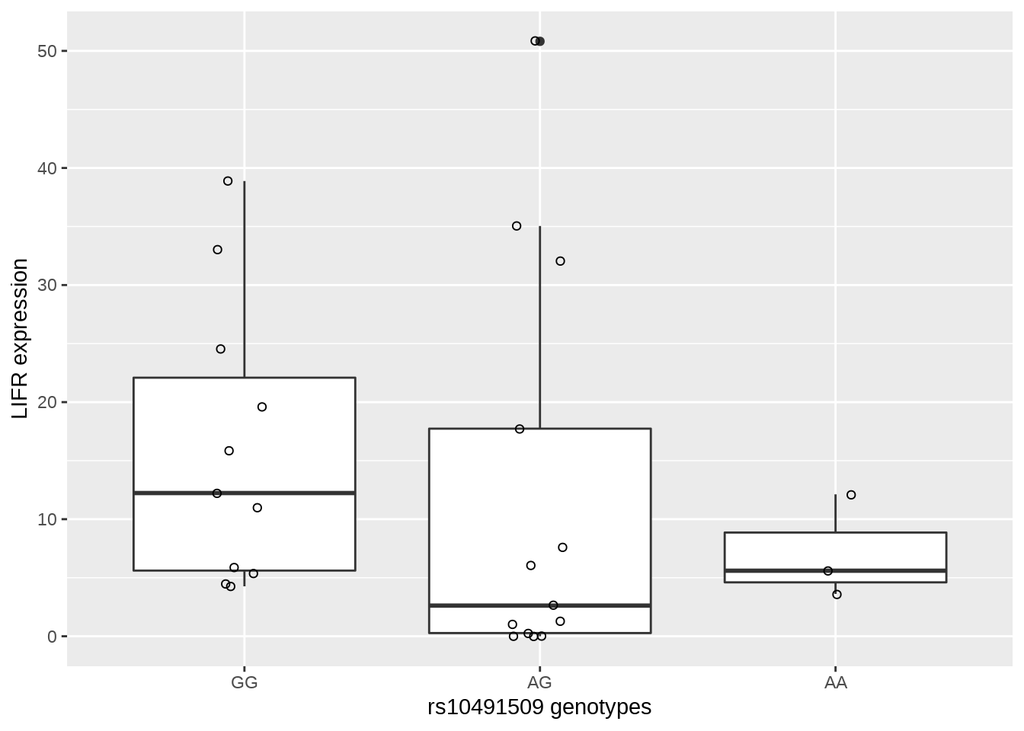

**Figure 15. Comparing LIFR expression between rs13168867 genotypes**

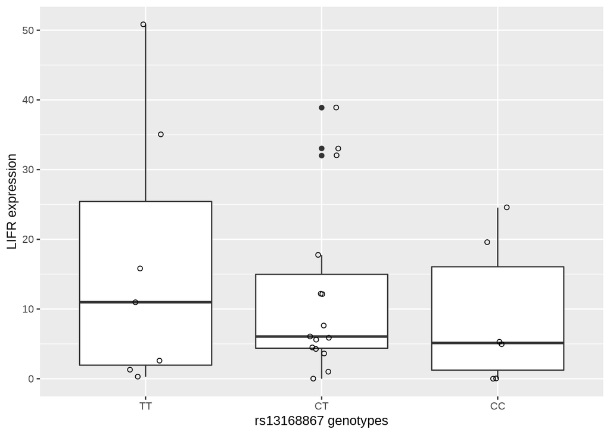

Above you can find the expression of both OSMR and LIFR over the different stability scores and genotypes.  
A few notes:  
- some groups contain few patients/samples  
- whether certain differences that appear to be there are truly different will have to be checked with differential expression (DE) analysis for these variables.

DE analysis will have to take place for every different phenotype, comparing gene expression between scores and/or genotypes (depending on phenotype). This will be done for all genes in the dataset, among which will be OSMR and LIFR. Right now, I’m setting up this workflow. Let me know whether you think you see differences in the plots above and are interested in analysing gene expression futher in one or more of the phenotypes.

If you need file versions of any of these figures, let me know which you want, and in what format (I’d suggest pdf or tiff).